# Assignment 3

Anne Tyvijärvi

This data includes information on student alcohol consumption, personal identifiers (age, sex, etc.), information about the family (education of parents, family size, etc.) and variables measuring the student’s success in school.

```
##  [1] "school"     "sex"        "age"        "address"    "famsize"
##  [6] "Pstatus"    "Medu"       "Fedu"       "Mjob"       "Fjob"
## [11] "reason"     "guardian"   "traveltime" "studytime"  "schoolsup"
## [16] "famsup"     "activities" "nursery"    "higher"     "internet"
## [21] "romantic"   "famrel"     "freetime"   "goout"      "Dalc"
## [26] "Walc"       "health"     "failures"   "paid"       "absences"
## [31] "G1"         "G2"         "G3"         "alc_use"    "high_use"
```

I decided to study the relationships between low/high alcohol consumption and parental education (“Medu” for mother’s education and “Fedu” for father’s education), student’s current health status (“health”) and quality of family relationships (“famrel”).

I hypothesize that

1. low level of education of either parent is associated with higher alcohol consumption in students
2. the health status of a student is associated with higher alcohol consumption
3. frequent alcohol use is associated with the quality of the relationship with the family

The mean age of the students was 16.6 years. The mean score for alcohol consumption (on a scale of 1 to 5, where 1 = very low consumption and 5 = very high consumption) was 1.9, indicating a moderate level of alcohol consumption across the data set. The mean scores for the education levels of the students mother and father were 2.8 and 2.6, indicating a slightly higher level of education for the mothers compared to fathers. Over all, the students health levels were really good (mean score 3.6), and in addition, the quality of the family relationships was really good (mean score of 3.9). The count summaries support the above findings.

```
## [1] 16.6
```

```
## [1] 1.9
```

```
## [1] 2.8
```

```
## [1] 2.6
```

```
## [1] 3.6
```

```
## [1] 3.9
```

```
## # A tibble: 7 × 2
##     age count
##   <dbl> <int>
## 1    15    81
## 2    16   102
## 3    17    97
## 4    18    77
## 5    19    11
## 6    20     1
## 7    22     1
```

```
## # A tibble: 9 × 2
##   alc_use count
##     <dbl> <int>
## 1     1     140
## 2     1.5    63
## 3     2      56
## 4     2.5    41
## 5     3      32
## 6     3.5    17
## 7     4       9
## 8     4.5     3
## 9     5       9
```

```
## # A tibble: 5 × 2
##    Medu count
##   <dbl> <int>
## 1     0     3
## 2     1    49
## 3     2    96
## 4     3    93
## 5     4   129
```

```
## # A tibble: 5 × 2
##    Fedu count
##   <dbl> <int>
## 1     0     2
## 2     1    73
## 3     2   105
## 4     3    97
## 5     4    93
```

```
## # A tibble: 5 × 2
##   health count
##    <dbl> <int>
## 1      1    46
## 2      2    42
## 3      3    80
## 4      4    62
## 5      5   140
```

```
## # A tibble: 5 × 2
##   famrel count
##    <dbl> <int>
## 1      1     8
## 2      2    18
## 3      3    64
## 4      4   180
## 5      5   100
```

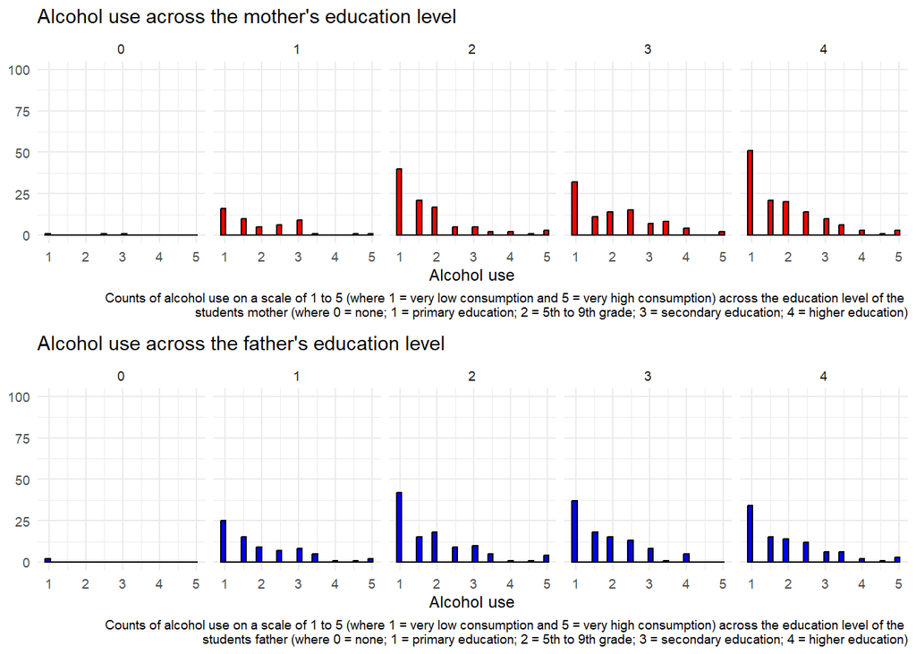

In addition, in contrast to my second and third hypotheses, either poor health score or poor family relationships did not seem to be associated with more frequent alcohol use.

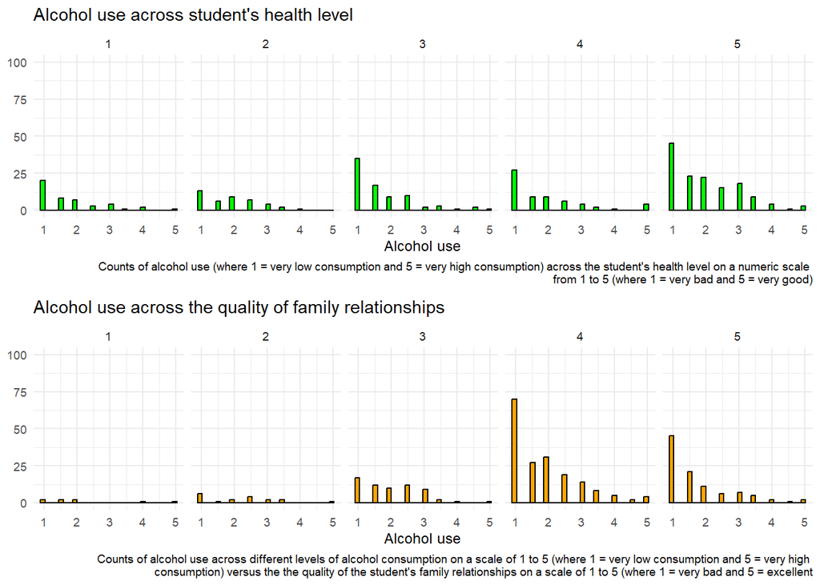

Now, let’s see if there are statistically significant differences associated with the variables that I’ve chosen and high alcohol use. Let’s set the “family = binomial” to let R know that the dependent variable high_use is binary (TRUE/FALSE).

Summary of the model shows a significant (p < 0.05 ) relationship between the quality of family relationships and high alcohol use. In addition, there is a trend of the health score being associated with high alcohol use (p < 0.1).

```
##
## Call:
## glm(formula = high_use ~ Medu + Fedu + health + famrel, family = "binomial",
##     data = alc)
##
## Coefficients:
##             Estimate Std. Error z value Pr(>|z|)
## (Intercept) -0.18242    0.63354  -0.288   0.7734
## Medu        -0.01537    0.13745  -0.112   0.9110
## Fedu         0.02092    0.13709   0.153   0.8787
## health       0.14777    0.08482   1.742   0.0815 .
## famrel      -0.31087    0.12454  -2.496   0.0126 *
## ---
## Signif. codes:  0 '***' 0.001 '**' 0.01 '*' 0.05 '.' 0.1 ' ' 1
##
## (Dispersion parameter for binomial family taken to be 1)
##
##     Null deviance: 452.04  on 369  degrees of freedom
## Residual deviance: 443.49  on 365  degrees of freedom
## AIC: 453.49
##
## Number of Fisher Scoring iterations: 4
```

```
## (Intercept)        Medu        Fedu      health      famrel
## -0.18242217 -0.01536970  0.02092328  0.14777237 -0.31086747
```

Since the education of either parent does not explain high alcohol use, let’s remove them from the model see and see how that looks. Let’s also look at the coefficients/odd ratios and provide confidence intervals for them.

The summary shows a small increase/improvement in the p - value for “health”. From the coefficients and confidence interval output we can see that the odds of variable “health” is ~1.16, meaning that exposure to “high_use” was associated with higher odds of outcome for health. For family relationships (famrel), the odd ratio was 0.7 meaning that the exposure to “high_use” was associated with lower odds of outcome for the quality of family relationships. Around 30% of the variance in “health odd ratio” can be explained with 97,5% confidence interval (which is OK?), but for famrel the value is below zero (which is not good, I assume :D)

```
##
## Call:
## glm(formula = high_use ~ health + famrel, family = "binomial",
##     data = alc)
##
## Coefficients:
##             Estimate Std. Error z value Pr(>|z|)
## (Intercept) -0.17461    0.54626  -0.320   0.7492
## health       0.14850    0.08465   1.754   0.0794 .
## famrel      -0.31083    0.12454  -2.496   0.0126 *
## ---
## Signif. codes:  0 '***' 0.001 '**' 0.01 '*' 0.05 '.' 0.1 ' ' 1
##
## (Dispersion parameter for binomial family taken to be 1)
##
##     Null deviance: 452.04  on 369  degrees of freedom
## Residual deviance: 443.51  on 367  degrees of freedom
## AIC: 449.51
##
## Number of Fisher Scoring iterations: 4
```

```
##             odd_ratios       2.5 %      97.5 %
## (Intercept)  0.8397865 -1.25837614  0.89223235
## health       1.1600907 -0.01507081  0.31752786
## famrel       0.7328380 -0.55725045 -0.06718336
```

Next, let’s explore the predictive power of our model glm2. The prediction got 256 (out of possible 259) FALSE observations “right”, so here the prediction works quite efficiently. However, when it comes to TRUE observations in the data, the prediction was not able to predict any of them (so the “result” is 0/111, which to me, sounds bad). Since I’m not a data scientist and this is my first time performing such analysis, I’m not quite sure how to interpret this. I’m sure (?) something in our model is not as is should be (I know at least that the variables health and famrel are not anywhere near normally distributed, so maybe that is one thing..?). The average number of incorrect predictions with probability 0 was 0.3, and with probability 1 it was 0.7.This means that when we have a binary (TRUE/FALSE and “positive”/“negative”) problem, any prediction that is set with the probability of 0 is the prediction for “FALSE” or “negative” => in our case, the average number of incorrect predictions for “FALSE” is 0.3, where as for “TRUE” it is 0.7. This was also reflected in the cross tabulation where the prediction failed with all TRUE predictions.

```
##         prediction
## high_use FALSE TRUE
##    FALSE   256    3
##    TRUE    111    0
```

```
## [1] 0.3
```

```
## [1] 0.7
```

As final words I would like to declare that I put a lot of time and effort in these exercises, and although I might have not interpreted the results “correctly” and made a few mistakes, I really tried my best and gave it a 100 % effort. :) I hope you (whoever grades this) appreciate the effort I made (being new to all these things shows…) :)